# Risk Factor Analysis

## Outcome Variable

**Outcome Variable:** ever_wasted

## Predictor Variables

**Intervention Variable:** feducyrs

**Adjustment Set:**

unadjusted

## Stratifying Variables

The analysis was stratified on these variable(s):

- agecat
- studyid
- country

## Data Summary

| agecat | studyid | country | feducyrs | ever_wasted | n_cell | n |
| --- | --- | --- | --- | --- | --- | --- |
| 0-24 months | COHORTS | GUATEMALA | High | 0 | 164 | 1234 |
| 0-24 months | COHORTS | GUATEMALA | High | 1 | 67 | 1234 |
| 0-24 months | COHORTS | GUATEMALA | Low | 0 | 419 | 1234 |
| 0-24 months | COHORTS | GUATEMALA | Low | 1 | 139 | 1234 |
| 0-24 months | COHORTS | GUATEMALA | Medium | 0 | 330 | 1234 |
| 0-24 months | COHORTS | GUATEMALA | Medium | 1 | 115 | 1234 |
| 0-24 months | COHORTS | INDIA | High | 0 | 386 | 1447 |
| 0-24 months | COHORTS | INDIA | High | 1 | 181 | 1447 |
| 0-24 months | COHORTS | INDIA | Low | 0 | 305 | 1447 |
| 0-24 months | COHORTS | INDIA | Low | 1 | 167 | 1447 |
| 0-24 months | COHORTS | INDIA | Medium | 0 | 269 | 1447 |
| 0-24 months | COHORTS | INDIA | Medium | 1 | 139 | 1447 |
| 0-24 months | COHORTS | PHILIPPINES | High | 0 | 640 | 2868 |
| 0-24 months | COHORTS | PHILIPPINES | High | 1 | 388 | 2868 |
| 0-24 months | COHORTS | PHILIPPINES | Low | 0 | 480 | 2868 |
| 0-24 months | COHORTS | PHILIPPINES | Low | 1 | 346 | 2868 |
| 0-24 months | COHORTS | PHILIPPINES | Medium | 0 | 597 | 2868 |
| 0-24 months | COHORTS | PHILIPPINES | Medium | 1 | 417 | 2868 |
| 0-24 months | GMS-Nepal | NEPAL | High | 0 | 65 | 684 |
| 0-24 months | GMS-Nepal | NEPAL | High | 1 | 104 | 684 |
| 0-24 months | GMS-Nepal | NEPAL | Low | 0 | 115 | 684 |
| 0-24 months | GMS-Nepal | NEPAL | Low | 1 | 177 | 684 |
| 0-24 months | GMS-Nepal | NEPAL | Medium | 0 | 100 | 684 |
| 0-24 months | GMS-Nepal | NEPAL | Medium | 1 | 123 | 684 |
| 0-24 months | JiVitA-3 | BANGLADESH | High | 0 | 4908 | 25970 |
| 0-24 months | JiVitA-3 | BANGLADESH | High | 1 | 1569 | 25970 |
| 0-24 months | JiVitA-3 | BANGLADESH | Low | 0 | 7799 | 25970 |
| 0-24 months | JiVitA-3 | BANGLADESH | Low | 1 | 2838 | 25970 |
| 0-24 months | JiVitA-3 | BANGLADESH | Medium | 0 | 6580 | 25970 |
| 0-24 months | JiVitA-3 | BANGLADESH | Medium | 1 | 2276 | 25970 |

[output cut: 330 more lines]

The following strata were considered:

- agecat: 0-24 months, studyid: COHORTS, country: GUATEMALA
- agecat: 0-24 months, studyid: COHORTS, country: INDIA
- agecat: 0-24 months, studyid: COHORTS, country: PHILIPPINES
- agecat: 0-24 months, studyid: GMS-Nepal, country: NEPAL
- agecat: 0-24 months, studyid: JiVitA-3, country: BANGLADESH
- agecat: 0-24 months, studyid: JiVitA-4, country: BANGLADESH
- agecat: 0-24 months, studyid: LCNI-5, country: MALAWI
- agecat: 0-24 months, studyid: MAL-ED, country: BANGLADESH
- agecat: 0-24 months, studyid: MAL-ED, country: INDIA
- agecat: 0-24 months, studyid: MAL-ED, country: NEPAL
- agecat: 0-24 months, studyid: MAL-ED, country: PERU
- agecat: 0-24 months, studyid: MAL-ED, country: SOUTH AFRICA
- agecat: 0-24 months, studyid: MAL-ED, country: TANZANIA, UNITED REPUBLIC OF
- agecat: 0-24 months, studyid: NIH-Crypto, country: BANGLADESH
- agecat: 0-24 months, studyid: PROBIT, country: BELARUS
- agecat: 0-24 months, studyid: PROVIDE, country: BANGLADESH
- agecat: 0-24 months, studyid: SAS-CompFeed, country: INDIA
- agecat: 0-24 months, studyid: SAS-FoodSuppl, country: INDIA
- agecat: 0-24 months, studyid: TanzaniaChild2, country: TANZANIA, UNITED REPUBLIC OF
- agecat: 0-24 months, studyid: ZVITAMBO, country: ZIMBABWE
- agecat: 0-6 months, studyid: COHORTS, country: GUATEMALA
- agecat: 0-6 months, studyid: COHORTS, country: INDIA
- agecat: 0-6 months, studyid: COHORTS, country: PHILIPPINES
- agecat: 0-6 months, studyid: GMS-Nepal, country: NEPAL
- agecat: 0-6 months, studyid: JiVitA-3, country: BANGLADESH
- agecat: 0-6 months, studyid: JiVitA-4, country: BANGLADESH
- agecat: 0-6 months, studyid: LCNI-5, country: MALAWI
- agecat: 0-6 months, studyid: MAL-ED, country: BANGLADESH
- agecat: 0-6 months, studyid: MAL-ED, country: INDIA
- agecat: 0-6 months, studyid: MAL-ED, country: NEPAL
- agecat: 0-6 months, studyid: MAL-ED, country: PERU
- agecat: 0-6 months, studyid: MAL-ED, country: SOUTH AFRICA
- agecat: 0-6 months, studyid: MAL-ED, country: TANZANIA, UNITED REPUBLIC OF
- agecat: 0-6 months, studyid: NIH-Crypto, country: BANGLADESH
- agecat: 0-6 months, studyid: PROBIT, country: BELARUS
- agecat: 0-6 months, studyid: PROVIDE, country: BANGLADESH
- agecat: 0-6 months, studyid: SAS-CompFeed, country: INDIA
- agecat: 0-6 months, studyid: SAS-FoodSuppl, country: INDIA
- agecat: 0-6 months, studyid: TanzaniaChild2, country: TANZANIA, UNITED REPUBLIC OF
- agecat: 0-6 months, studyid: ZVITAMBO, country: ZIMBABWE
- agecat: 6-24 months, studyid: COHORTS, country: GUATEMALA
- agecat: 6-24 months, studyid: COHORTS, country: INDIA
- agecat: 6-24 months, studyid: COHORTS, country: PHILIPPINES
- agecat: 6-24 months, studyid: GMS-Nepal, country: NEPAL
- agecat: 6-24 months, studyid: JiVitA-3, country: BANGLADESH
- agecat: 6-24 months, studyid: JiVitA-4, country: BANGLADESH
- agecat: 6-24 months, studyid: LCNI-5, country: MALAWI
- agecat: 6-24 months, studyid: MAL-ED, country: BANGLADESH
- agecat: 6-24 months, studyid: MAL-ED, country: INDIA
- agecat: 6-24 months, studyid: MAL-ED, country: NEPAL
- agecat: 6-24 months, studyid: MAL-ED, country: PERU
- agecat: 6-24 months, studyid: MAL-ED, country: SOUTH AFRICA
- agecat: 6-24 months, studyid: MAL-ED, country: TANZANIA, UNITED REPUBLIC OF
- agecat: 6-24 months, studyid: NIH-Crypto, country: BANGLADESH
- agecat: 6-24 months, studyid: PROBIT, country: BELARUS
- agecat: 6-24 months, studyid: PROVIDE, country: BANGLADESH
- agecat: 6-24 months, studyid: SAS-CompFeed, country: INDIA
- agecat: 6-24 months, studyid: SAS-FoodSuppl, country: INDIA
- agecat: 6-24 months, studyid: TanzaniaChild2, country: TANZANIA, UNITED REPUBLIC OF
- agecat: 6-24 months, studyid: ZVITAMBO, country: ZIMBABWE

### Dropped Strata

Some strata were dropped due to rare outcomes:

- agecat: 0-24 months, studyid: MAL-ED, country: PERU
- agecat: 0-24 months, studyid: MAL-ED, country: TANZANIA, UNITED REPUBLIC OF
- agecat: 0-6 months, studyid: LCNI-5, country: MALAWI
- agecat: 0-6 months, studyid: MAL-ED, country: NEPAL
- agecat: 0-6 months, studyid: MAL-ED, country: PERU
- agecat: 0-6 months, studyid: MAL-ED, country: SOUTH AFRICA
- agecat: 0-6 months, studyid: MAL-ED, country: TANZANIA, UNITED REPUBLIC OF
- agecat: 6-24 months, studyid: MAL-ED, country: NEPAL
- agecat: 6-24 months, studyid: MAL-ED, country: PERU
- agecat: 6-24 months, studyid: MAL-ED, country: SOUTH AFRICA
- agecat: 6-24 months, studyid: MAL-ED, country: TANZANIA, UNITED REPUBLIC OF

## Methods Detail

We’re interested in the causal parameters $E[Y_a]$ for all values of $a \in \mathcal{A}$. These parameters represent the mean outcome if, possibly contrary to fact, we intervened to set all units to have $A=a$. Under the randomization and positivity assumptions, these are identified by the statistical parameters $\psi_a=E_W[E_{Y|A,W}(Y|A=a,W)]$. In addition, we’re interested in the mean of $Y$, $E[Y]$ under no intervention (the observed mean). We will estimate these parameters by using SuperLearner to fit the relevant likelihood factors – $E_{Y|A,W}(Y|A=a,W)$ and $p(A=a|W)$, and then updating our likelihood fit using a joint TMLE.

For unadjusted analyses ($W=\{\}$), initial likelihoods were estimated using Lrnr_glm to estimate the simple $E(Y|A)$ and Lrnr_mean to estimate $p(A)$. For adjusted analyses, a small library containing Lrnr_glmnet, Lrnr_xgboost, and Lrnr_mean was used.

Having estimated these parameters, we will then use the delta method to estimate relative risks and attributable risks relative to a prespecified baseline level of $A$.

# Results Detail

## Results Plots

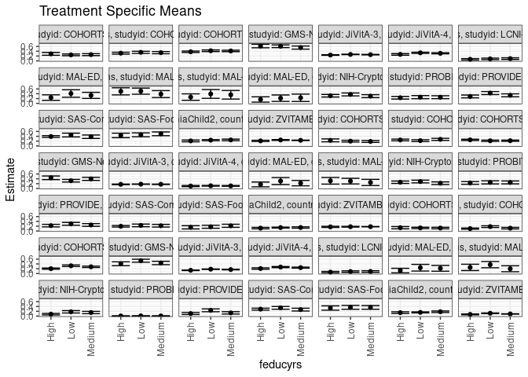

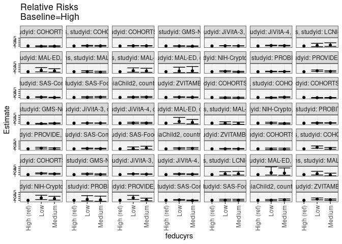

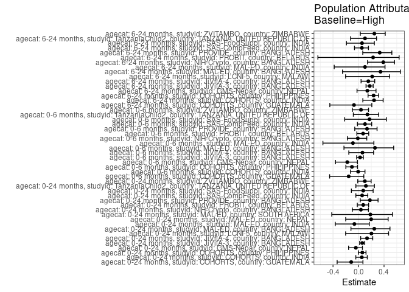

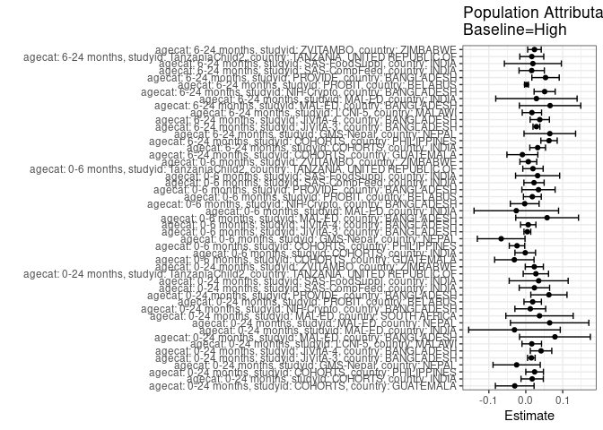

## Results Table

### Parameter: TSM

| agecat | studyid | country | intervention_level | baseline_level | estimate | ci_lower | ci_upper |
| --- | --- | --- | --- | --- | --- | --- | --- |
| 0-24 months | COHORTS | GUATEMALA | High | NA | 0.2900433 | 0.2315016 | 0.3485850 |
| 0-24 months | COHORTS | GUATEMALA | Low | NA | 0.2491039 | 0.2132045 | 0.2850033 |
| 0-24 months | COHORTS | GUATEMALA | Medium | NA | 0.2584270 | 0.2177367 | 0.2991172 |
| 0-24 months | COHORTS | INDIA | High | NA | 0.3192240 | 0.2808394 | 0.3576085 |
| 0-24 months | COHORTS | INDIA | Low | NA | 0.3538136 | 0.3106623 | 0.3969648 |
| 0-24 months | COHORTS | INDIA | Medium | NA | 0.3406863 | 0.2946827 | 0.3866898 |
| 0-24 months | COHORTS | PHILIPPINES | High | NA | 0.3774319 | 0.3477945 | 0.4070693 |
| 0-24 months | COHORTS | PHILIPPINES | Low | NA | 0.4188862 | 0.3852341 | 0.4525383 |
| 0-24 months | COHORTS | PHILIPPINES | Medium | NA | 0.4112426 | 0.3809510 | 0.4415342 |
| 0-24 months | GMS-Nepal | NEPAL | High | NA | 0.6153846 | 0.5419824 | 0.6887868 |
| 0-24 months | GMS-Nepal | NEPAL | Low | NA | 0.6061644 | 0.5500819 | 0.6622468 |
| 0-24 months | GMS-Nepal | NEPAL | Medium | NA | 0.5515695 | 0.4862473 | 0.6168917 |
| 0-24 months | JiVitA-3 | BANGLADESH | High | NA | 0.2422418 | 0.2298117 | 0.2546719 |
| 0-24 months | JiVitA-3 | BANGLADESH | Low | NA | 0.2668046 | 0.2574263 | 0.2761828 |
| 0-24 months | JiVitA-3 | BANGLADESH | Medium | NA | 0.2570009 | 0.2465162 | 0.2674856 |
| 0-24 months | JiVitA-4 | BANGLADESH | High | NA | 0.2686447 | 0.2347605 | 0.3025290 |
| 0-24 months | JiVitA-4 | BANGLADESH | Low | NA | 0.3331627 | 0.3088387 | 0.3574867 |
| 0-24 months | JiVitA-4 | BANGLADESH | Medium | NA | 0.3131021 | 0.2908487 | 0.3353556 |
| 0-24 months | LCNI-5 | MALAWI | High | NA | 0.0637450 | 0.0335038 | 0.0939862 |
| 0-24 months | LCNI-5 | MALAWI | Low | NA | 0.0824742 | 0.0508487 | 0.1140997 |
| 0-24 months | LCNI-5 | MALAWI | Medium | NA | 0.0922509 | 0.0577763 | 0.1267255 |
| 0-24 months | MAL-ED | BANGLADESH | High | NA | 0.2407407 | 0.1263204 | 0.3551611 |
| 0-24 months | MAL-ED | BANGLADESH | Low | NA | 0.4102564 | 0.2553543 | 0.5651585 |
| 0-24 months | MAL-ED | BANGLADESH | Medium | NA | 0.3333333 | 0.2071717 | 0.4594949 |
| 0-24 months | MAL-ED | INDIA | High | NA | 0.5000000 | 0.3517571 | 0.6482429 |
| 0-24 months | MAL-ED | INDIA | Low | NA | 0.5084746 | 0.3804740 | 0.6364752 |
| 0-24 months | MAL-ED | INDIA | Medium | NA | 0.3863636 | 0.2420001 | 0.5307272 |
| 0-24 months | MAL-ED | NEPAL | High | NA | 0.2619048 | 0.1282518 | 0.3955577 |
| 0-24 months | MAL-ED | NEPAL | Low | NA | 0.3928571 | 0.2110299 | 0.5746844 |
| 0-24 months | MAL-ED | NEPAL | Medium | NA | 0.3571429 | 0.1787512 | 0.5355345 |

[output cut: 117 more lines]

### Parameter: E(Y)

| agecat | studyid | country | intervention_level | baseline_level | estimate | ci_lower | ci_upper |
| --- | --- | --- | --- | --- | --- | --- | --- |
| 0-24 months | COHORTS | GUATEMALA | NA | NA | 0.2601297 | 0.2356425 | 0.2846169 |
| 0-24 months | COHORTS | INDIA | NA | NA | 0.3365584 | 0.3122030 | 0.3609138 |
| 0-24 months | COHORTS | PHILIPPINES | NA | NA | 0.4013250 | 0.3833827 | 0.4192673 |
| 0-24 months | GMS-Nepal | NEPAL | NA | NA | 0.5906433 | 0.5537666 | 0.6275199 |
| 0-24 months | JiVitA-3 | BANGLADESH | NA | NA | 0.2573354 | 0.2507501 | 0.2639207 |
| 0-24 months | JiVitA-4 | BANGLADESH | NA | NA | 0.3100246 | 0.2953385 | 0.3247108 |
| 0-24 months | LCNI-5 | MALAWI | NA | NA | 0.0799508 | 0.0612962 | 0.0986054 |
| 0-24 months | MAL-ED | BANGLADESH | NA | NA | 0.3197279 | 0.2440789 | 0.3953769 |
| 0-24 months | MAL-ED | INDIA | NA | NA | 0.4693878 | 0.3884360 | 0.5503395 |
| 0-24 months | MAL-ED | NEPAL | NA | NA | 0.3265306 | 0.2332088 | 0.4198524 |
| 0-24 months | MAL-ED | SOUTH AFRICA | NA | NA | 0.2000000 | 0.1249078 | 0.2750922 |
| 0-24 months | NIH-Crypto | BANGLADESH | NA | NA | 0.3298153 | 0.2963239 | 0.3633067 |
| 0-24 months | PROBIT | BELARUS | NA | NA | 0.2539381 | 0.1952340 | 0.3126422 |
| 0-24 months | PROVIDE | BANGLADESH | NA | NA | 0.3514286 | 0.3160364 | 0.3868207 |
| 0-24 months | SAS-CompFeed | INDIA | NA | NA | 0.4145695 | 0.3576236 | 0.4715155 |
| 0-24 months | SAS-FoodSuppl | INDIA | NA | NA | 0.4712919 | 0.4233811 | 0.5192026 |
| 0-24 months | TanzaniaChild2 | TANZANIA, UNITED REPUBLIC OF | NA | NA | 0.2366765 | 0.2196074 | 0.2537455 |
| 0-24 months | ZVITAMBO | ZIMBABWE | NA | NA | 0.2337854 | 0.2266636 | 0.2409072 |
| 0-6 months | COHORTS | GUATEMALA | NA | NA | 0.2006018 | 0.1757323 | 0.2254713 |
| 0-6 months | COHORTS | INDIA | NA | NA | 0.2462950 | 0.2238538 | 0.2687361 |
| 0-6 months | COHORTS | PHILIPPINES | NA | NA | 0.2291594 | 0.2137721 | 0.2445467 |
| 0-6 months | GMS-Nepal | NEPAL | NA | NA | 0.3771930 | 0.3408437 | 0.4135423 |
| 0-6 months | JiVitA-3 | BANGLADESH | NA | NA | 0.1757592 | 0.1700164 | 0.1815020 |
| 0-6 months | JiVitA-4 | BANGLADESH | NA | NA | 0.1079224 | 0.0978937 | 0.1179511 |
| 0-6 months | MAL-ED | BANGLADESH | NA | NA | 0.2244898 | 0.1568093 | 0.2921703 |
| 0-6 months | MAL-ED | INDIA | NA | NA | 0.2925170 | 0.2187257 | 0.3663083 |
| 0-6 months | NIH-Crypto | BANGLADESH | NA | NA | 0.2572559 | 0.2261171 | 0.2883948 |
| 0-6 months | PROBIT | BELARUS | NA | NA | 0.2485900 | 0.1897185 | 0.3074615 |
| 0-6 months | PROVIDE | BANGLADESH | NA | NA | 0.2585714 | 0.2261125 | 0.2910304 |
| 0-6 months | SAS-CompFeed | INDIA | NA | NA | 0.2197071 | 0.1750081 | 0.2644060 |
| 0-6 months | SAS-FoodSuppl | INDIA | NA | NA | 0.1866029 | 0.1492099 | 0.2239959 |
| 0-6 months | TanzaniaChild2 | TANZANIA, UNITED REPUBLIC OF | NA | NA | 0.1397398 | 0.1258162 | 0.1536634 |
| 0-6 months | ZVITAMBO | ZIMBABWE | NA | NA | 0.1794777 | 0.1729988 | 0.1859566 |
| 6-24 months | COHORTS | GUATEMALA | NA | NA | 0.1288889 | 0.1093000 | 0.1484778 |
| 6-24 months | COHORTS | INDIA | NA | NA | 0.1323843 | 0.1146569 | 0.1501118 |
| 6-24 months | COHORTS | PHILIPPINES | NA | NA | 0.2666667 | 0.2498425 | 0.2834908 |
| 6-24 months | GMS-Nepal | NEPAL | NA | NA | 0.4719864 | 0.4316361 | 0.5123367 |
| 6-24 months | JiVitA-3 | BANGLADESH | NA | NA | 0.1643382 | 0.1581062 | 0.1705701 |
| 6-24 months | JiVitA-4 | BANGLADESH | NA | NA | 0.2467286 | 0.2329282 | 0.2605290 |
| 6-24 months | LCNI-5 | MALAWI | NA | NA | 0.0773067 | 0.0588111 | 0.0958024 |
| 6-24 months | MAL-ED | BANGLADESH | NA | NA | 0.1908397 | 0.1232893 | 0.2583901 |
| 6-24 months | MAL-ED | INDIA | NA | NA | 0.2846715 | 0.2088306 | 0.3605124 |
| 6-24 months | NIH-Crypto | BANGLADESH | NA | NA | 0.1315068 | 0.1069744 | 0.1560393 |
| 6-24 months | PROBIT | BELARUS | NA | NA | 0.0083609 | 0.0045540 | 0.0121678 |
| 6-24 months | PROVIDE | BANGLADESH | NA | NA | 0.1609756 | 0.1319065 | 0.1900447 |
| 6-24 months | SAS-CompFeed | INDIA | NA | NA | 0.3051948 | 0.2633957 | 0.3469939 |
| 6-24 months | SAS-FoodSuppl | INDIA | NA | NA | 0.3557214 | 0.3088651 | 0.4025777 |
| 6-24 months | TanzaniaChild2 | TANZANIA, UNITED REPUBLIC OF | NA | NA | 0.1602787 | 0.1442326 | 0.1763249 |
| 6-24 months | ZVITAMBO | ZIMBABWE | NA | NA | 0.0946306 | 0.0890328 | 0.1002285 |

### Parameter: RR

| agecat | studyid | country | intervention_level | baseline_level | estimate | ci_lower | ci_upper |
| --- | --- | --- | --- | --- | --- | --- | --- |
| 0-24 months | COHORTS | GUATEMALA | High | High | 1.0000000 | 1.0000000 | 1.0000000 |
| 0-24 months | COHORTS | GUATEMALA | Low | High | 0.8588509 | 0.6702082 | 1.1005906 |
| 0-24 months | COHORTS | GUATEMALA | Medium | High | 0.8909945 | 0.6897641 | 1.1509313 |
| 0-24 months | COHORTS | INDIA | High | High | 1.0000000 | 1.0000000 | 1.0000000 |
| 0-24 months | COHORTS | INDIA | Low | High | 1.1083552 | 0.9338951 | 1.3154059 |
| 0-24 months | COHORTS | INDIA | Medium | High | 1.0672327 | 0.8907063 | 1.2787444 |
| 0-24 months | COHORTS | PHILIPPINES | High | High | 1.0000000 | 1.0000000 | 1.0000000 |
| 0-24 months | COHORTS | PHILIPPINES | Low | High | 1.1098325 | 0.9919031 | 1.2417828 |
| 0-24 months | COHORTS | PHILIPPINES | Medium | High | 1.0895809 | 0.9783663 | 1.2134377 |
| 0-24 months | GMS-Nepal | NEPAL | High | High | 1.0000000 | 1.0000000 | 1.0000000 |
| 0-24 months | GMS-Nepal | NEPAL | Low | High | 0.9850171 | 0.8470029 | 1.1455199 |
| 0-24 months | GMS-Nepal | NEPAL | Medium | High | 0.8963004 | 0.7576257 | 1.0603581 |
| 0-24 months | JiVitA-3 | BANGLADESH | High | High | 1.0000000 | 1.0000000 | 1.0000000 |
| 0-24 months | JiVitA-3 | BANGLADESH | Low | High | 1.1013978 | 1.0376775 | 1.1690308 |
| 0-24 months | JiVitA-3 | BANGLADESH | Medium | High | 1.0609272 | 0.9962605 | 1.1297915 |
| 0-24 months | JiVitA-4 | BANGLADESH | High | High | 1.0000000 | 1.0000000 | 1.0000000 |
| 0-24 months | JiVitA-4 | BANGLADESH | Low | High | 1.2401610 | 1.0722817 | 1.4343240 |
| 0-24 months | JiVitA-4 | BANGLADESH | Medium | High | 1.1654876 | 1.0063468 | 1.3497945 |
| 0-24 months | LCNI-5 | MALAWI | High | High | 1.0000000 | 1.0000000 | 1.0000000 |
| 0-24 months | LCNI-5 | MALAWI | Low | High | 1.2938144 | 0.7029928 | 2.3811848 |
| 0-24 months | LCNI-5 | MALAWI | Medium | High | 1.4471863 | 0.7911260 | 2.6473004 |
| 0-24 months | MAL-ED | BANGLADESH | High | High | 1.0000000 | 1.0000000 | 1.0000000 |
| 0-24 months | MAL-ED | BANGLADESH | Low | High | 1.7041420 | 0.9287226 | 3.1269833 |
| 0-24 months | MAL-ED | BANGLADESH | Medium | High | 1.3846154 | 0.7541594 | 2.5421150 |
| 0-24 months | MAL-ED | INDIA | High | High | 1.0000000 | 1.0000000 | 1.0000000 |
| 0-24 months | MAL-ED | INDIA | Low | High | 1.0169492 | 0.6892628 | 1.5004227 |
| 0-24 months | MAL-ED | INDIA | Medium | High | 0.7727273 | 0.4795940 | 1.2450269 |
| 0-24 months | MAL-ED | NEPAL | High | High | 1.0000000 | 1.0000000 | 1.0000000 |
| 0-24 months | MAL-ED | NEPAL | Low | High | 1.5000000 | 0.7531655 | 2.9873912 |
| 0-24 months | MAL-ED | NEPAL | Medium | High | 1.3636364 | 0.6676922 | 2.7849720 |

[output cut: 117 more lines]

### Parameter: PAR

| agecat | studyid | country | intervention_level | baseline_level | estimate | ci_lower | ci_upper |
| --- | --- | --- | --- | --- | --- | --- | --- |
| 0-24 months | COHORTS | GUATEMALA | High | NA | -0.0299136 | -0.0822936 | 0.0224664 |
| 0-24 months | COHORTS | INDIA | High | NA | 0.0173344 | -0.0128631 | 0.0475319 |
| 0-24 months | COHORTS | PHILIPPINES | High | NA | 0.0238931 | 0.0000055 | 0.0477806 |
| 0-24 months | GMS-Nepal | NEPAL | High | NA | -0.0247413 | -0.0886580 | 0.0391753 |
| 0-24 months | JiVitA-3 | BANGLADESH | High | NA | 0.0150936 | 0.0048236 | 0.0253637 |
| 0-24 months | JiVitA-4 | BANGLADESH | High | NA | 0.0413799 | 0.0123428 | 0.0704170 |
| 0-24 months | LCNI-5 | MALAWI | High | NA | 0.0162058 | -0.0102108 | 0.0426223 |
| 0-24 months | MAL-ED | BANGLADESH | High | NA | 0.0789872 | -0.0169095 | 0.1748838 |
| 0-24 months | MAL-ED | INDIA | High | NA | -0.0306122 | -0.1546020 | 0.0933776 |
| 0-24 months | MAL-ED | NEPAL | High | NA | 0.0646259 | -0.0414912 | 0.1707429 |
| 0-24 months | MAL-ED | SOUTH AFRICA | High | NA | 0.0372093 | -0.0540031 | 0.1284218 |
| 0-24 months | NIH-Crypto | BANGLADESH | High | NA | 0.0122477 | -0.0294467 | 0.0539422 |
| 0-24 months | PROBIT | BELARUS | High | NA | 0.0187091 | -0.0048804 | 0.0422987 |
| 0-24 months | PROVIDE | BANGLADESH | High | NA | 0.0626355 | 0.0136372 | 0.1116337 |
| 0-24 months | SAS-CompFeed | INDIA | High | NA | 0.0233778 | -0.0177992 | 0.0645548 |
| 0-24 months | SAS-FoodSuppl | INDIA | High | NA | 0.0349282 | -0.0449075 | 0.1147640 |
| 0-24 months | TanzaniaChild2 | TANZANIA, UNITED REPUBLIC OF | High | NA | 0.0273223 | -0.0069446 | 0.0615893 |
| 0-24 months | ZVITAMBO | ZIMBABWE | High | NA | 0.0230999 | -0.0014066 | 0.0476064 |
| 0-6 months | COHORTS | GUATEMALA | High | NA | -0.0309771 | -0.0843370 | 0.0223827 |
| 0-6 months | COHORTS | INDIA | High | NA | -0.0014608 | -0.0293651 | 0.0264434 |
| 0-6 months | COHORTS | PHILIPPINES | High | NA | -0.0237589 | -0.0446531 | -0.0028647 |
| 0-6 months | GMS-Nepal | NEPAL | High | NA | -0.0665940 | -0.1311203 | -0.0020677 |
| 0-6 months | JiVitA-3 | BANGLADESH | High | NA | 0.0042863 | -0.0048964 | 0.0134691 |
| 0-6 months | JiVitA-4 | BANGLADESH | High | NA | 0.0066458 | -0.0140811 | 0.0273727 |
| 0-6 months | MAL-ED | BANGLADESH | High | NA | 0.0578231 | -0.0271469 | 0.1427932 |
| 0-6 months | MAL-ED | INDIA | High | NA | -0.0256648 | -0.1401162 | 0.0887866 |
| 0-6 months | NIH-Crypto | BANGLADESH | High | NA | -0.0028792 | -0.0418325 | 0.0360741 |
| 0-6 months | PROBIT | BELARUS | High | NA | 0.0177924 | -0.0062985 | 0.0418832 |
| 0-6 months | PROVIDE | BANGLADESH | High | NA | 0.0344335 | -0.0105749 | 0.0794419 |
| 0-6 months | SAS-CompFeed | INDIA | High | NA | 0.0223045 | -0.0050858 | 0.0496947 |
| 0-6 months | SAS-FoodSuppl | INDIA | High | NA | 0.0320574 | -0.0276489 | 0.0917637 |
| 0-6 months | TanzaniaChild2 | TANZANIA, UNITED REPUBLIC OF | High | NA | 0.0194726 | -0.0080628 | 0.0470079 |
| 0-6 months | ZVITAMBO | ZIMBABWE | High | NA | 0.0068888 | -0.0158605 | 0.0296381 |
| 6-24 months | COHORTS | GUATEMALA | High | NA | -0.0092063 | -0.0510318 | 0.0326191 |
| 6-24 months | COHORTS | INDIA | High | NA | 0.0322022 | 0.0109375 | 0.0534669 |
| 6-24 months | COHORTS | PHILIPPINES | High | NA | 0.0629830 | 0.0408737 | 0.0850924 |
| 6-24 months | GMS-Nepal | NEPAL | High | NA | 0.0650899 | -0.0047621 | 0.1349418 |
| 6-24 months | JiVitA-3 | BANGLADESH | High | NA | 0.0288338 | 0.0195432 | 0.0381243 |
| 6-24 months | JiVitA-4 | BANGLADESH | High | NA | 0.0378933 | 0.0117906 | 0.0639960 |
| 6-24 months | LCNI-5 | MALAWI | High | NA | 0.0165780 | -0.0095602 | 0.0427162 |
| 6-24 months | MAL-ED | BANGLADESH | High | NA | 0.0658397 | -0.0173452 | 0.1490246 |
| 6-24 months | MAL-ED | INDIA | High | NA | 0.0288576 | -0.0812767 | 0.1389918 |
| 6-24 months | NIH-Crypto | BANGLADESH | High | NA | 0.0510873 | 0.0225018 | 0.0796727 |
| 6-24 months | PROBIT | BELARUS | High | NA | 0.0019117 | -0.0033591 | 0.0071825 |
| 6-24 months | PROVIDE | BANGLADESH | High | NA | 0.0534990 | 0.0164930 | 0.0905050 |
| 6-24 months | SAS-CompFeed | INDIA | High | NA | 0.0160056 | -0.0182741 | 0.0502853 |
| 6-24 months | SAS-FoodSuppl | INDIA | High | NA | 0.0192728 | -0.0578841 | 0.0964297 |
| 6-24 months | TanzaniaChild2 | TANZANIA, UNITED REPUBLIC OF | High | NA | 0.0162787 | -0.0161124 | 0.0486699 |
| 6-24 months | ZVITAMBO | ZIMBABWE | High | NA | 0.0235009 | 0.0051427 | 0.0418591 |

### Parameter: PAF

| agecat | studyid | country | intervention_level | baseline_level | estimate | ci_lower | ci_upper |
| --- | --- | --- | --- | --- | --- | --- | --- |
| 0-24 months | COHORTS | GUATEMALA | High | NA | -0.1149951 | -0.3356090 | 0.0691782 |
| 0-24 months | COHORTS | INDIA | High | NA | 0.0515049 | -0.0425973 | 0.1371137 |
| 0-24 months | COHORTS | PHILIPPINES | High | NA | 0.0595354 | -0.0019267 | 0.1172273 |
| 0-24 months | GMS-Nepal | NEPAL | High | NA | -0.0418888 | -0.1559940 | 0.0609534 |
| 0-24 months | JiVitA-3 | BANGLADESH | High | NA | 0.0586535 | 0.0177912 | 0.0978157 |
| 0-24 months | JiVitA-4 | BANGLADESH | High | NA | 0.1334729 | 0.0335917 | 0.2230311 |
| 0-24 months | LCNI-5 | MALAWI | High | NA | 0.2026969 | -0.2022753 | 0.4712590 |
| 0-24 months | MAL-ED | BANGLADESH | High | NA | 0.2470449 | -0.1189307 | 0.4933186 |
| 0-24 months | MAL-ED | INDIA | High | NA | -0.0652174 | -0.3652769 | 0.1688953 |
| 0-24 months | MAL-ED | NEPAL | High | NA | 0.1979167 | -0.2011331 | 0.4643910 |
| 0-24 months | MAL-ED | SOUTH AFRICA | High | NA | 0.1860465 | -0.4198366 | 0.5333827 |
| 0-24 months | NIH-Crypto | BANGLADESH | High | NA | 0.0371351 | -0.0979534 | 0.1556028 |
| 0-24 months | PROBIT | BELARUS | High | NA | 0.0736760 | -0.0194323 | 0.1582804 |
| 0-24 months | PROVIDE | BANGLADESH | High | NA | 0.1782310 | 0.0264289 | 0.3063637 |
| 0-24 months | SAS-CompFeed | INDIA | High | NA | 0.0563906 | -0.0418538 | 0.1453708 |
| 0-24 months | SAS-FoodSuppl | INDIA | High | NA | 0.0741117 | -0.1119031 | 0.2290073 |
| 0-24 months | TanzaniaChild2 | TANZANIA, UNITED REPUBLIC OF | High | NA | 0.1154417 | -0.0417379 | 0.2489057 |
| 0-24 months | ZVITAMBO | ZIMBABWE | High | NA | 0.0988081 | -0.0123348 | 0.1977488 |
| 0-6 months | COHORTS | GUATEMALA | High | NA | -0.1544211 | -0.4531960 | 0.0829262 |
| 0-6 months | COHORTS | INDIA | High | NA | -0.0059313 | -0.1258536 | 0.1012173 |
| 0-6 months | COHORTS | PHILIPPINES | High | NA | -0.1036784 | -0.1986289 | -0.0162496 |
| 0-6 months | GMS-Nepal | NEPAL | High | NA | -0.1765515 | -0.3610989 | -0.0170264 |
| 0-6 months | JiVitA-3 | BANGLADESH | High | NA | 0.0243876 | -0.0293619 | 0.0753305 |
| 0-6 months | JiVitA-4 | BANGLADESH | High | NA | 0.0615794 | -0.1526473 | 0.2359908 |
| 0-6 months | MAL-ED | BANGLADESH | High | NA | 0.2575758 | -0.2285454 | 0.5513444 |
| 0-6 months | MAL-ED | INDIA | High | NA | -0.0877378 | -0.5585357 | 0.2408428 |
| 0-6 months | NIH-Crypto | BANGLADESH | High | NA | -0.0111920 | -0.1745329 | 0.1294334 |
| 0-6 months | PROBIT | BELARUS | High | NA | 0.0715731 | -0.0261841 | 0.1600177 |
| 0-6 months | PROVIDE | BANGLADESH | High | NA | 0.1331682 | -0.0592168 | 0.2906105 |
| 0-6 months | SAS-CompFeed | INDIA | High | NA | 0.1015191 | -0.0173762 | 0.2065197 |
| 0-6 months | SAS-FoodSuppl | INDIA | High | NA | 0.1717949 | -0.2170762 | 0.4364168 |
| 0-6 months | TanzaniaChild2 | TANZANIA, UNITED REPUBLIC OF | High | NA | 0.1393487 | -0.0816372 | 0.3151857 |
| 0-6 months | ZVITAMBO | ZIMBABWE | High | NA | 0.0383827 | -0.0970984 | 0.1571332 |
| 6-24 months | COHORTS | GUATEMALA | High | NA | -0.0714286 | -0.4502719 | 0.2084525 |
| 6-24 months | COHORTS | INDIA | High | NA | 0.2432477 | 0.0674593 | 0.3858992 |
| 6-24 months | COHORTS | PHILIPPINES | High | NA | 0.2361863 | 0.1492748 | 0.3142189 |
| 6-24 months | GMS-Nepal | NEPAL | High | NA | 0.1379062 | -0.0238534 | 0.2741093 |
| 6-24 months | JiVitA-3 | BANGLADESH | High | NA | 0.1754537 | 0.1175413 | 0.2295656 |
| 6-24 months | JiVitA-4 | BANGLADESH | High | NA | 0.1535828 | 0.0397185 | 0.2539458 |
| 6-24 months | LCNI-5 | MALAWI | High | NA | 0.2144443 | -0.2028818 | 0.4869839 |
| 6-24 months | MAL-ED | BANGLADESH | High | NA | 0.3450000 | -0.2511462 | 0.6570944 |
| 6-24 months | MAL-ED | INDIA | High | NA | 0.1013715 | -0.3817356 | 0.4155660 |
| 6-24 months | NIH-Crypto | BANGLADESH | High | NA | 0.3884761 | 0.1417210 | 0.5642892 |
| 6-24 months | PROBIT | BELARUS | High | NA | 0.2286509 | -0.6372667 | 0.6366020 |
| 6-24 months | PROVIDE | BANGLADESH | High | NA | 0.3323421 | 0.0662098 | 0.5226261 |
| 6-24 months | SAS-CompFeed | INDIA | High | NA | 0.0524439 | -0.0633361 | 0.1556174 |
| 6-24 months | SAS-FoodSuppl | INDIA | High | NA | 0.0541795 | -0.1896159 | 0.2480123 |
| 6-24 months | TanzaniaChild2 | TANZANIA, UNITED REPUBLIC OF | High | NA | 0.1015652 | -0.1248504 | 0.2824067 |
| 6-24 months | ZVITAMBO | ZIMBABWE | High | NA | 0.2483436 | 0.0276175 | 0.4189660 |